# Project Python Foundations: FoodHub Data Analysis

**Marks: 40**

### Roman Dzadzic | 09/30/2021

### Context

The number of restaurants in New York is increasing day by day. Lots of students and busy professionals rely on those restaurants due to their hectic lifestyles. Online food delivery service is a great option for them. It provides them with good food from their favorite restaurants. A food aggregator company FoodHub offers access to multiple restaurants through a single smartphone app.

The app allows the restaurants to receive a direct online order from a customer. The app assigns a delivery person from the company to pick up the order after it is confirmed by the restaurant. The delivery person then uses the map to reach the restaurant and waits for the food package. Once the food package is handed over to the delivery person, he/she confirms the pick-up in the app and travels to the customer's location to deliver the food. The delivery person confirms the drop-off in the app after delivering the food package to the customer. The customer can rate the order in the app. The food aggregator earns money by collecting a fixed margin of the delivery order from the restaurants.

### Objective

The food aggregator company has stored the data of the different orders made by the registered customers in their online portal. They want to analyze the data to **get a fair idea about the demand of different restaurants which will help them in enhancing their customer experience**. Suppose you are hired as a Data Scientist in this company and the Data Science team has shared some of the key questions that need to be answered. Perform the data analysis to find answers to these questions that will help the company to improve the business.

### Data Description

The data contains the different data related to a food order. The detailed data dictionary is given below.

### Data Dictionary

- order_id: Unique ID of the order
- customer_id: ID of the customer who ordered the food
- restaurant_name: Name of the restaurant
- cuisine_type: Cuisine ordered by the customer
- cost: Cost of the order
- day_of_the_week: Indicates whether the order is placed on a weekday or weekend (The weekday is from Monday to Friday and the weekend is Saturday and Sunday)
- rating: Rating given by the customer out of 5
- food_preparation_time: Time (in minutes) taken by the restaurant to prepare the food. This is calculated by taking the difference between the timestamps of the restaurant's order confirmation and the delivery person's pick-up confirmation.
- delivery_time: Time (in minutes) taken by the delivery person to deliver the food package. This is calculated by taking the difference between the timestamps of the delivery person's pick-up confirmation and drop-off information

### Let us start by importing the required libraries

```python
# import libraries for data manipulation
import numpy as np
import pandas as pd

# import libraries for data visualization
import matplotlib.pyplot as plt
import seaborn as sns
%matplotlib inline
```

```python
# Library to suppress warnings or deprecation notes
import warnings
warnings.filterwarnings('ignore')
```

### Understanding the structure of the data

```python
# read the data
df = pd.read_csv('foodhub_order.csv')
# returns the first 5 rows
df.head()
```

|  | order_id | customer_id | restaurant_name | cuisine_type | cost_of_the_order | day_of_the_week | rating | food_preparation_time | delivery_time |
| --- | --- | --- | --- | --- | --- | --- | --- | --- | --- |
| 0 | 1477004 | 250494 | Five Guys Burgers and Fries | American | 33.03 | Weekend | 5 | 29 | 15 |
| 1 | 1477334 | 106968 | Blue Ribbon Fried Chicken | American | 29.20 | Weekend | 3 | 25 | 15 |
| 2 | 1477856 | 143984 | The Smile | American | 25.17 | Weekend | 3 | 31 | 15 |
| 3 | 1477503 | 99621 | Westville Hudson | American | 24.30 | Weekend | Not given | 32 | 15 |
| 4 | 1478397 | 121706 | Blue Ribbon Fried Chicken | American | 24.30 | Weekend | 5 | 22 | 15 |

#### Observations:

- The DataFrame has 9 columns as mentioned in the Data Dictionary. Data in each row corresponds to the order placed by a customer.
- The 'rating' column can have numeric values or a label 'Not given'.
- The 'day_of_the_week' column has either a label named 'Weekend' or a label named 'Weekday'.
- Each transaction has two ID type records: 'order_id' and 'customer_id'.
- The 'restaurant_name' column has restaurant names, and 'cuisine_type' column has names of different cuisines.

### **Question 1:** Write the code to check the shape of the dataset and write your observations based on that. (0.5 mark)

```python
# write your code here
df.shape # using data shape understand the dataset
```

```
(1898, 9)
```

#### Observations: The dataset has 1,898 rows and 9 columns.

### Question 2: Write the observations based on the below output from the info() method. (0.5 mark)

```python
# using info() to print a concise summary of the DataFrame
df.info()
```

```
<class 'pandas.core.frame.DataFrame'>
RangeIndex: 1898 entries, 0 to 1897
Data columns (total 9 columns):
 #   Column                 Non-Null Count  Dtype
---  ------                 --------------  -----
 0   order_id               1898 non-null   int64
 1   customer_id            1898 non-null   int64
 2   restaurant_name        1898 non-null   object
 3   cuisine_type           1898 non-null   object
 4   cost_of_the_order      1898 non-null   float64
 5   day_of_the_week        1898 non-null   object
 6   rating                 1898 non-null   object
 7   food_preparation_time  1898 non-null   int64
 8   delivery_time          1898 non-null   int64
dtypes: float64(1), int64(4), object(4)
memory usage: 133.6+ KB
```

#### Observations:

- All column have 1,898 data points/observations which means that neither of the columns have missing data.
- 'restaurant_name', 'cuisine_type', and 'day_of_the_week' should be categorical variables, and we should convert them as such.
- 'cost_of_the_order' is represented as float64 (decimal number).
- 'order_id', 'customer_id', 'food_preparation_time', and 'delivery_time' are represented as int64.

### Question 3: 'restaurant_name', 'cuisine_type', 'day_of_the_week' are object types. Write the code to convert the mentioned features to 'category' and write your observations on the same. (0.5 mark)

```python
# converting "objects" to "category" reduces the data space required to store the dataframe
# the code used to convert 'restaurant_name', 'cuisine_type', 'day_of_the_week' into categorical data

df['restaurant_name'] = df.restaurant_name.astype('category') # as type used with all 3 categories
df['cuisine_type'] = df.cuisine_type.astype('category')
df['day_of_the_week'] = df.day_of_the_week.astype('category')

# use info() to print a concise summary of the dataset to verify the action
df.info()
```

```
<class 'pandas.core.frame.DataFrame'>
RangeIndex: 1898 entries, 0 to 1897
Data columns (total 9 columns):
 #   Column                 Non-Null Count  Dtype
---  ------                 --------------  -----
 0   order_id               1898 non-null   int64
 1   customer_id            1898 non-null   int64
 2   restaurant_name        1898 non-null   category
 3   cuisine_type           1898 non-null   category
 4   cost_of_the_order      1898 non-null   float64
 5   day_of_the_week        1898 non-null   category
 6   rating                 1898 non-null   object
 7   food_preparation_time  1898 non-null   int64
 8   delivery_time          1898 non-null   int64
dtypes: category(3), float64(1), int64(4), object(1)
memory usage: 102.7+ KB
```

#### Observations:

- There are now 5 numeric columns (four int64 and one float64), 3 categorical columns, and 1 object column.
- All data types are changed as expected.

### **Question 4:** Write the code to find the summary statistics and write your observations based on that. (1 mark)

```python
# write your code here

df.describe() # using describe() to observe the summary statistic
```

|  | order_id | customer_id | cost_of_the_order | food_preparation_time | delivery_time |
| --- | --- | --- | --- | --- | --- |
| count | 1.898000e+03 | 1898.000000 | 1898.000000 | 1898.000000 | 1898.000000 |
| mean | 1.477496e+06 | 171168.478398 | 16.498851 | 27.371970 | 24.161749 |
| std | 5.480497e+02 | 113698.139743 | 7.483812 | 4.632481 | 4.972637 |
| min | 1.476547e+06 | 1311.000000 | 4.470000 | 20.000000 | 15.000000 |
| 25% | 1.477021e+06 | 77787.750000 | 12.080000 | 23.000000 | 20.000000 |
| 50% | 1.477496e+06 | 128600.000000 | 14.140000 | 27.000000 | 25.000000 |
| 75% | 1.477970e+06 | 270525.000000 | 22.297500 | 31.000000 | 28.000000 |
| max | 1.478444e+06 | 405334.000000 | 35.410000 | 35.000000 | 33.000000 |

#### Observations:

- Summary statistics confirms the count of 1,898 records across all observations.
- 'food_preparation_time' and 'delivery_time' appear to have similar data. I expect that we will also likely notice this during univariate analysis.
- Minimum 'cost_of_the_order' can be really small (4.47) compared to the maximum value (35.41) - a bit wider range, but the upper range is not outrageous.

### **Question 5:** How many orders are not rated? (0.5 mark)

```python
# using the 'len' to find the 'length' of orders that contain the 'Not given' rating label.

len(df[df['rating'] == 'Not given'])
```

```
736
```

#### Observations:

- There are 736 orders that are not rated (marked with 'Not given').

### Exploratory Data Analysis (EDA)

### **Question 6:** Explore all the variables and provide observations on the distributions of all the relevant variables in the dataset. (5 marks)

```python
# Univariate charts go here...

# For univariate analysis of numerical variables, looking at their central tendency and dispersion.
# The below function mimics closely that of the Uber case, and helps create a boxplot and histogram for...
# ... any input numerical variable.
# This function takes the numerical column as the input and returns the boxplots + histograms for the variable.
# The function allows me to plot a boxplot and a histogram along the same scale for better visibility.
# Also, with 3 quotes below is the text that would be used if somebody search for help on this function.


def histogram_boxplot(data, feature, figsize=(12, 7), kde=False, bins=None):
    """
    Boxplot and histogram combined

    data: dataframe
    feature: dataframe column
    figsize: size of figure (default (12,7))
    kde: whether to show the density curve (default False)
    bins: number of bins for histogram (default None)
    """

    f2, (ax_box2, ax_hist2) = plt.subplots(
        nrows=2,  # Number of rows of the subplot grid= 2
        sharex=True,  # x-axis will be shared among all subplots
        gridspec_kw={"height_ratios": (0.25, 0.75)},
        figsize=figsize,
    )  # creating the 2 subplots
    sns.boxplot(
        data=data, x=feature, ax=ax_box2, showmeans=True, color="violet"
    )  # boxplot will be created and a star will indicate the mean value of the column
    sns.histplot(
        data=data, x=feature, kde=kde, ax=ax_hist2, bins=bins, palette="winter"
    ) if bins else sns.histplot(
        data=data, x=feature, kde=kde, ax=ax_hist2
    )  # For histogram
    ax_hist2.axvline(
        data[feature].mean(), color="green", linestyle="--"
    )  # Add mean to the histogram
    ax_hist2.axvline(
        data[feature].median(), color="black", linestyle="-"
    )  # Add median to the histogram
```

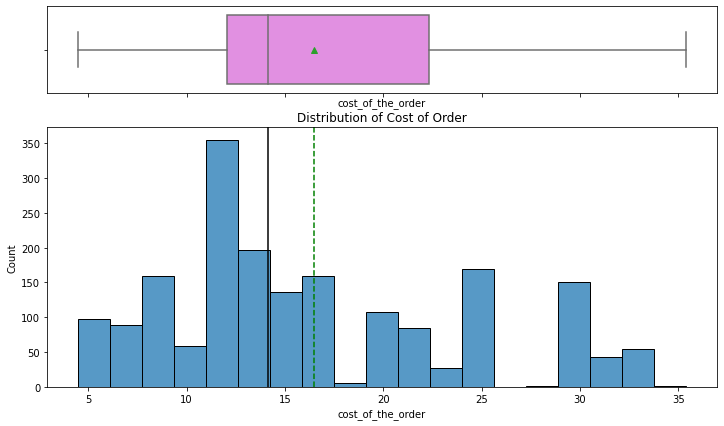

```python
histogram_boxplot(df, 'cost_of_the_order')
plt.title('Distribution of Cost of Order')
```

#### Observations:

- The distribution of the cost of the order is somewhat right skewed.
- There are close to 350 orders at a cost of around 12 dollars.
- The IQR seems to be located between 12.5 and 22.5 dollars.
- Median cost of orders (solid black line) is close to 14 dollars, and the mean (green dashed line) is close to 16 dollars, so just 2 dollars higher than the mean.
- There is a wide range of orders, from around 4 dollars all the way to just over 35 dollars.

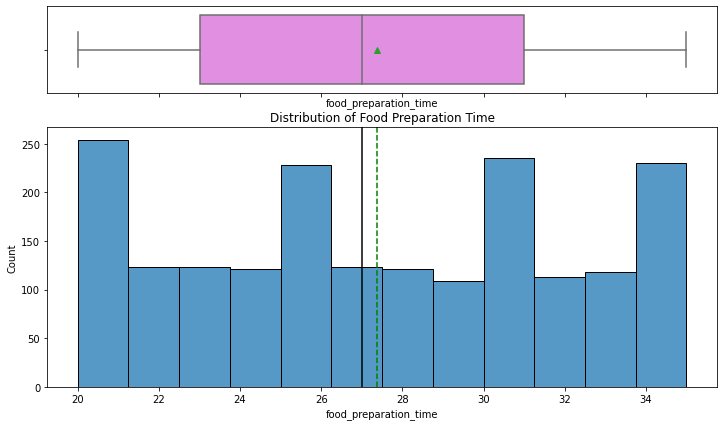

```python
histogram_boxplot(df, 'food_preparation_time')
plt.title('Distribution of Food Preparation Time')
```

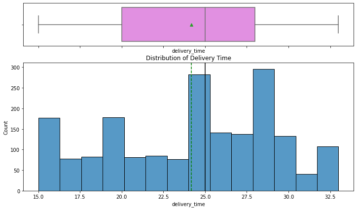

```python
histogram_boxplot(df, 'delivery_time')
plt.title('Distribution of Delivery Time')
```

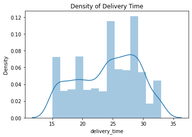

```python
sns.distplot(df['delivery_time']);
plt.title('Density of Delivery Time')
```

#### Observations (both charts above):

- The 'delivery_time' seems like a left skew distribution and with multiple peaks, including the highest peak around 28.5 delivery minutes.
- Median time (solid black line) is relatively close to the mean time (green dashed line) with a small left skew.
- The distribution of the delivery time is pretty uniformly distributed with almost equal but lower counts in the the first 50% of the distribution, and somewhat higher number of counts on the right side of of the median, so there are likely more delivery times that are over 25 minutes than there are delivery times below the 25 minute delivery time.
- There is a 2nd peak in the curve around 28.5 minutes of delivery time with nearly 300 counts and right around the 75% quartile range.
- There are 4 delivery time peaks in this distribution as well.
- The IQR range is located between 20 and 28.5 minutes.
- Delivery times range from 15 to 33 minutes.

### Categorical Data Analysis

```python
# function to create labeled barplots

def labeled_barplot(data, feature, perc=False, n=None):
    """
    Barplot with percentage at the top

    data: dataframe
    feature: dataframe column
    perc: whether to display percentages instead of count (default is False)
    n: displays the top n category levels (default is None, i.e., display all levels)
    """

    total = len(data[feature])  # length of the column
    count = data[feature].nunique()
    if n is None:
        plt.figure(figsize=(count + 1, 5))
    else:
        plt.figure(figsize=(n + 1, 5))

    plt.xticks(rotation=90, fontsize=15)
    ax = sns.countplot(
        data=data,
        x=feature,
        palette="Paired",
        order=data[feature].value_counts().index[:n].sort_values(),
    )

    for p in ax.patches:
        if perc == True:
            label = "{:.1f}%".format(
                100 * p.get_height() / total
            )  # percentage of each class of the category
        else:
            label = p.get_height()  # count of each level of the category

        x = p.get_x() + p.get_width() / 2  # width of the plot
        y = p.get_height()  # height of the plot

        ax.annotate(
            label,
            (x, y),
            ha="center",
            va="center",
            size=12,
            xytext=(0, 5),
            textcoords="offset points",
        )  # annotate the percentage

    plt.show()  # show the plot
```

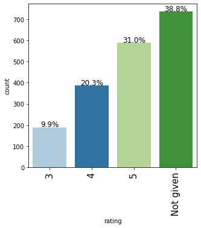

```python
plt.figure(figsize=(10,7))
labeled_barplot(df, 'rating', perc=True)
```

#### Observations:

- The largest number of rating observations is without a rating (rating 'Not given') at around 39%
- There are no ratings below rating = 3, which could mean that the company is doing a relatively good job without poor ratings.
- The difference between ratings of 3, 4, and 5 increases approximately 10 percentage points respectively.
- The largest number of given ratings is 5 at 31% of all ratings.
- From the further analysis, it would be great to understand why as many as 38.8% of all possible ratings were not provided ('Not given'), and what type of cuisines, restorants, or delivery times have the best and the worst ratings, so that the company can improve its customer satisfaction.

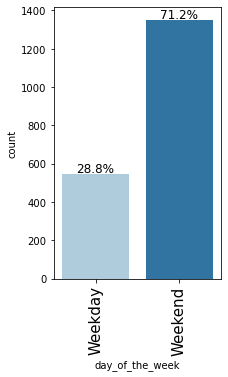

```python
plt.figure(figsize=(10,7))
labeled_barplot(df, 'day_of_the_week', perc=True)
```

### Observations:

- Surprisingly, the largest number of observed orders are happening on weekends (71.2%). I would have thought that possibly weekday lunch orders would be larger due to work lunch orders, but that doesn't seem to be the case.
- From the further analysis, it would be great to understand which specific days (if data is available) have the most observed orders in order to understand how to distribute drivers during those days.
- It would also be great to understand which days have the best order reviews.

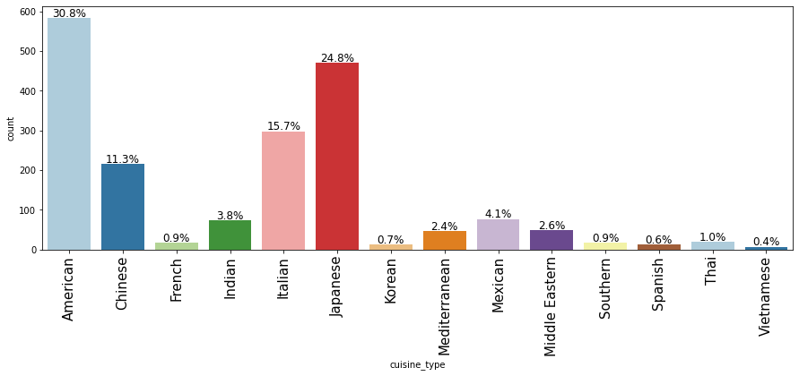

```python
# looking at the most popular cuisine type
plt.figure(figsize=(10,7))
labeled_barplot(df, 'cuisine_type', perc=True)
```

### Observations:

- Looks like the top 4 cuisines (in descending order) and perhaps intuitively are: American, Japanese, Italian, and Chinese.
- The least consumed cuisines (in ascending order) are: Vietnamese, Spanish, Korean, and French.
- In further analysis, it might be interesting to understand how the surrounding population demographics influences orders and reviews.

### Question 7: Write the code to find the top 5 restaurants that have received the highest number of orders. (1 mark)

```python
# write the code here

# grouping orders by restaurant name on order_id
df.groupby(['restaurant_name'])['order_id'].count().sort_values(ascending=False)
```

```
restaurant_name
Shake Shack                  219
The Meatball Shop            132
Blue Ribbon Sushi            119
Blue Ribbon Fried Chicken     96
Parm                          68
                            ...
Klong                          1
Kambi Ramen House              1
Il Bambino                     1
Hunan Manor                    1
Lamarca Pasta                  1
Name: order_id, Length: 178, dtype: int64
```

#### Observations:

- Top 5 restaurants are Shake Shack, The Meatball Shop, Blue Ribbon Sushi, Blue Ribbon Fried Chicken, followed by Parm.
- The bottom 5 restaurants are Klong, Kambi Ramen House, Il Bambino, Hunan Manor, and Lamarca Pasta.

### Question 8: Write the code to find the most popular cuisine on weekends. (1 mark)

```python
# write the code here
df1 = df.copy() # I copied the dataframe to ensure that the original is not altered - just in case.
```

```python
# here I observed the most popular cuisine on weekends

df_weekend = df1[df1.day_of_the_week=='Weekend']
df_weekend.groupby(['cuisine_type'])['order_id'].count().sort_values(ascending=False)
```

```
cuisine_type
American          415
Japanese          335
Italian           207
Chinese           163
Mexican            53
Indian             49
Mediterranean      32
Middle Eastern     32
Thai               15
French             13
Korean             11
Southern           11
Spanish            11
Vietnamese          4
Name: order_id, dtype: int64
```

```python
# I was also curious about the most popular cuisine on weekdays

df_weekday = df1[df1.day_of_the_week=='Weekday']
df_weekday.groupby(['cuisine_type'])['order_id'].count().sort_values(ascending=False)
```

```
cuisine_type
American          169
Japanese          135
Italian            91
Chinese            52
Indian             24
Mexican            24
Middle Eastern     17
Mediterranean      14
Southern            6
French              5
Thai                4
Vietnamese          3
Korean              2
Spanish             1
Name: order_id, dtype: int64
```

#### Observations:

- Seems like the most popular cuisine on weekends is the 'American' cuisine.
- American cuisine is also the most popular cuisine on weekdays.
- The top four (4) cuisine types do not change from weekdays to weekends, and they're 'American', 'Japanese', 'Italian', and 'Chinese'.
- The position number 5 changes as follows: on weekends, Mexican cuisine is the 5th most popular, while on weekdays, Indian cuisine is the 5th most popular.

### Question 9: Write the code to find the number of total orders where the cost is above 20 dollars. What is the percentage of such orders in the dataset? (1 mark)

```python
# write the code here

# the following code find the number of orders where the cost is above $20 dollars
cost_over_20=df1[df1.cost_of_the_order>20]['order_id'].count()
print("Total number of orders over 20 dollars:", cost_over_20)

revenue_over_20=df1[df1.cost_of_the_order>20]['cost_of_the_order'].sum()
print("Total revenue of orders over 20 dollars: ${:,.2f}".format(revenue_over_20))

# this code finds the total number of orders, so that we can later calculate the percentage
total_orders=df1['order_id'].count()
print("Total number of orders:",total_orders)

total_orders_revenue=df1['cost_of_the_order'].sum()
print("Total revenue processed for all orders: ${:,.2f}".format(total_orders_revenue))
```

```
Total number of orders over 20 dollars: 555
Total revenue of orders over 20 dollars: $14,754.91
Total number of orders: 1898
Total revenue processed for all orders: $31,314.82
```

```python
# finally calculating the percentage

percentage_number = (cost_over_20/total_orders)*100  # divide orders over $20 by total orders
print("Percentage of orders over $20 dollars:", round(percentage_number,2),'%') # using the 'round' function

percentage_revenue = (revenue_over_20/total_orders_revenue)*100
print("Percentage of revenue for orders over $20 dollars:", round(percentage_revenue,2),'%')
```

```
Percentage of orders over $20 dollars: 29.24 %
Percentage of revenue for orders over $20 dollars: 47.12 %
```

#### Observations:

- There are 555 orders in the dataset that are over 20 dollars.
- Looked as percentage, over 29% of all orders in the total set are over 20 dollars, or almost 1/3 of all orders.
- However, as a percentage of total revenue, orders over 20 dollars represent almost 50% (or 47.12%).

### Question 10: Write the code to find the mean delivery time based on this dataset. (1 mark)

```python
# write the code here

# using the mean() function on delivery time for all orders.
delivery_mean=df1['delivery_time'].mean()
print("Delivery mean for all orders is:", round(delivery_mean,2))
```

```
Delivery mean for all orders is: 24.16
```

```python
# using the mean() function on orders over $20
mean_over_20=df1[df1.cost_of_the_order>20]['delivery_time'].mean()
mean_over_20
print("Delivery mean for orders over 20 dollars is:", round(mean_over_20,2))
```

```
Delivery mean for orders over 20 dollars is: 24.01
```

#### Observations:

- Delivery means for both, total orders and orders over 20 dollars, are similar - around 24 minutes.

### Question 11: Suppose the company has decided to give a free coupon of 15 dollars to the customer who has spent the maximum amount on a single order. Write the code to find the ID of the customer along with the order details. (1 mark)

```python
# write the code here

# this code calls the max cost_of_the_order value, and delivers the entire record associated with that order.

print("Order details for the highest/maximum 'cost_of_the_order':\n\n",
      df[df.cost_of_the_order == df.cost_of_the_order.max()])
```

```
Order details for the highest/maximum 'cost_of_the_order':

       order_id  customer_id restaurant_name   cuisine_type  cost_of_the_order  \
1705   1477814        62359           Pylos  Mediterranean              35.41

     day_of_the_week rating  food_preparation_time  delivery_time
1705         Weekday      4                     21             29
```

#### Observations:

- The maximum amount of a single order is 35.41 dollars.
- This customer ordered food from Pylos, which is a Mediterranean cuisine restaurant.
- The *total* delivery time for this order was 50 minutes.
- This order received a rating of 4.

### Question 12: Perform bivariate/multivariate analysis to explore relationships between the important variables in the dataset. (7 marks)

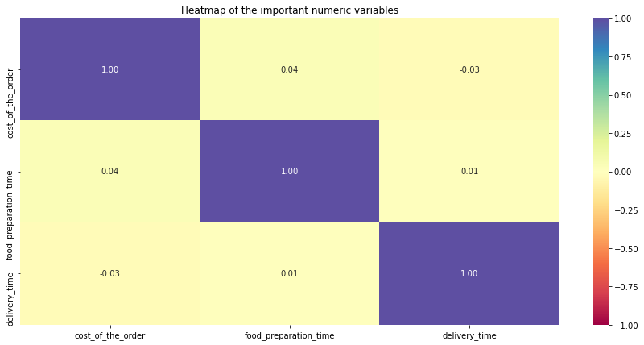

```python
# Bivariate and multivariate charts go here...

# Correlation among numerical variables
num_var = ['cost_of_the_order','food_preparation_time','delivery_time']
corr = df[num_var].corr()

# plot the heatmap
plt.figure(figsize=(15, 7))
sns.heatmap(corr, annot=True, vmin=-1, vmax=1, fmt=".2f", cmap="Spectral", xticklabels=corr.columns, yticklabels=corr.columns)
plt.title('Heatmap of the important numeric variables')
plt.show()
```

### Observations:

- In the above chart, I don't see a significant correlation between any of the observed variables.

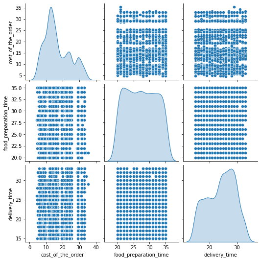

```python
# using sns pairplot to see if there are any correlations amongst the observable variables.
sns.pairplot(data=df[num_var], diag_kind="kde")
plt.show()
```

### Observations:

- In the above two charts, I don't see a significant correlation between any of the observed variables.
- Cost of order distribution feels right scewed, while delivery time feels left scewed.

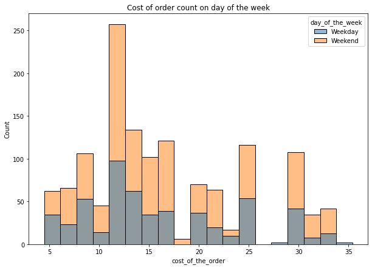

```python
# using histplot to observe cost of the order counts with hue on day of the week.
plt.figure(figsize=(10,7))
sns.histplot(x='cost_of_the_order',data=df,hue=df['day_of_the_week'])
plt.title('Cost of order count on day of the week')
plt.show()
```

#### Observations:

- From the above histplot, we can see that the count of orders between 11 and 17 dollars happens more on weekends.
- There are two other count peaks around 25 and 30 dollar cost of order sizes.

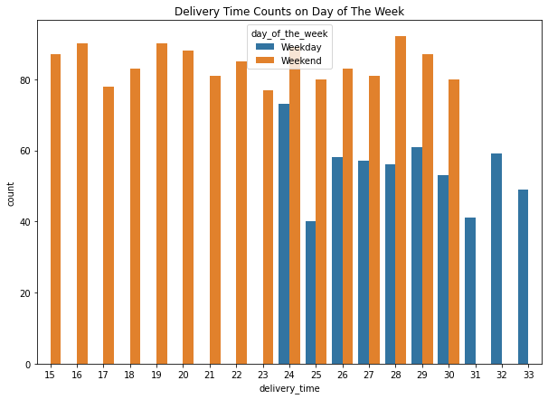

```python
# looking at delivery time countplot with hue on day of the week.
plt.figure(figsize=(10,7))
sns.countplot(x='delivery_time',data=df,hue=df['day_of_the_week'])
plt.title('Delivery Time Counts on Day of The Week')
plt.show()
```

#### Observations:

- From the above countplot, we can see that orders between 15 and 23 minutes happen only on weekends. This is also likely indicating that the traffic on those days is more favorable to our delivery times.
- Similarly, we can see that a count of very high delivery times (between 31 and 33 minutes) happens only on weekdays.

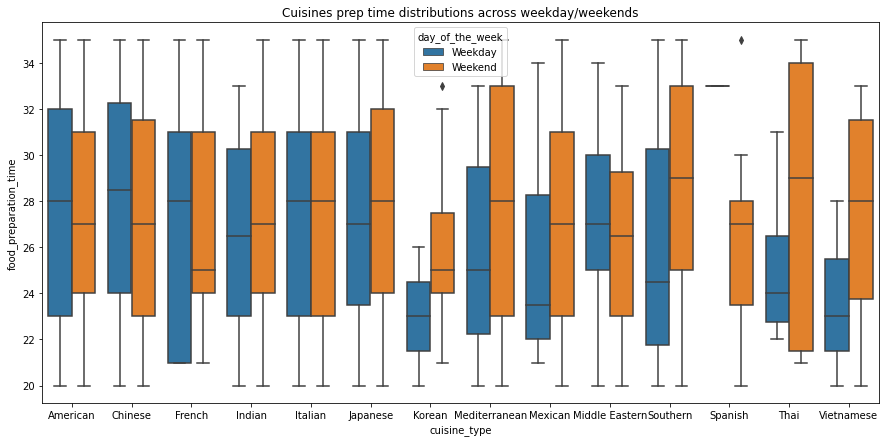

```python
# looking at cuisine food preparation times with hue on day of the week.
plt.figure(figsize=(15,7))
sns.boxplot(df['cuisine_type'],df['food_preparation_time'],hue=df['day_of_the_week'])
plt.title('Cuisines prep time distributions across weekday/weekends')
plt.show()
```

#### Observations:

- While most cuisine types have similar food preparation times, Korean seems to lead in terms of record food preparation speeds on both weekdays and weekends.
- Thai cuisine has the biggest IQR range on weekends, from 22 to 34, while weekdays are one of the lowest ranges of all cuisines, except for Vietnamese and Korean.
- Spanish cuisine seems almost completely gone from weekdays, while on weekends they have decent food preparation times.
- And last but not least, French cuisine has the lowest 25th percentile of all cuisines at 21.

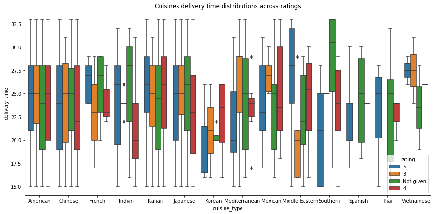

```python
# looking at cuisine delivery time distributions with hue on ratings.
plt.figure(figsize=(15,7))
sns.boxplot(df['cuisine_type'],df['delivery_time'],hue=df['rating'])
plt.title('Cuisines delivery time distributions across ratings')
plt.show()
```

#### Observations:

- Interestingly, for the top 4 cuisines (American, Japanese, Italian, and Chinese), they have consistent delivery time distributions across all 4 ratings.
- Indian cuisine receives very few ratings of 3, just like Southern, while Spanish, and Thai get no 3s.
- Middle Eastern cuisine receives 5s at highest IQR delivery times distribution while lower delivery time distributions have mostly rating of 3 (seems very counterintuitive), but perhaps long times spent on waiting for food are associated with the quality of food?!?
- Meanwhile, Southern cuisine 'Not given' IQR seems to be associated almost exlusively at 26 minutes and higher.

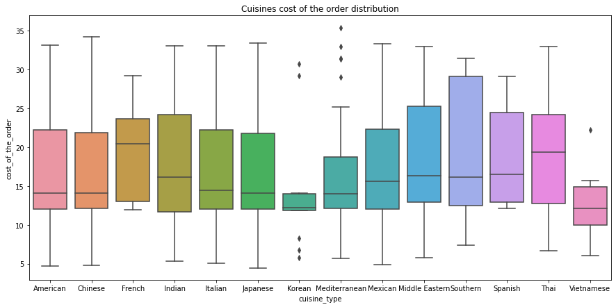

```python
# looking at cuisine type against the cost of the order distribution.
plt.figure(figsize=(15,7))
sns.boxplot(df['cuisine_type'],df['cost_of_the_order'])
plt.title('Cuisines cost of the order distribution')
plt.show()
```

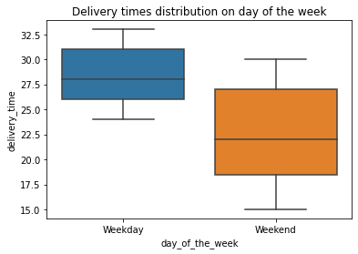

```python
# exploring day of the week against delivery time.
sns.boxplot(df['day_of_the_week'],df['delivery_time'])
plt.title('Delivery times distribution on day of the week')
plt.show()
```

#### Observations:

- During the weekends, range of delivery times span from 15 to 30 minutes, with IQR from 18 to 27 minutes.
- During the weekdays, range of delivery times shifts considerably towards the range of 24 to 33 minutes, with IQR from 26 to 31 minutes. This could potentially indicate that during weekday rush hour, most orders take longer to be delivered.

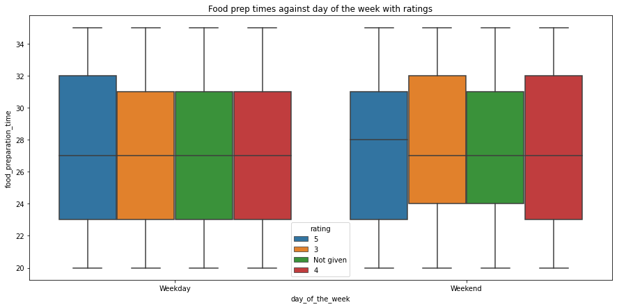

```python
plt.figure(figsize=(15,7))
sns.boxplot(df['day_of_the_week'],df['food_preparation_time'], hue=df['rating']) # adding hue on ratings
plt.title('Food prep times against day of the week with ratings')
plt.show()
```

#### Observations:

- During the weekends, food preparation times with slightly higher 75th percentile distributions seem to represent lower ratings of 3 and 4. We could intuitively assume that during weekends, slightly longer upper percentile food preparation times are more prone to the lower rating marks -- below 5.
- During the weekdays, rating of 5 seems to represent a slightly higher 75th percentile distribution of food prep times, which seems a bit counterintuitive. One could possibly expect to see lower ratings on increased 75th percentile of food prep times on weekdays, but that might not be the case here.
- Otherwise, food preparation times seem to have a pretty equal representation on weekdays amongst all rating values.

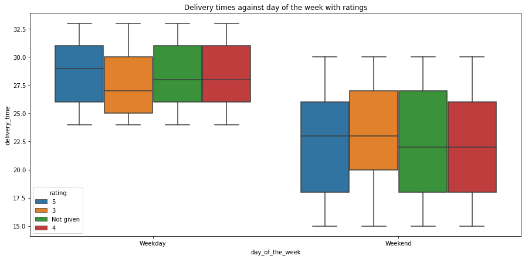

```python
plt.figure(figsize=(15,7))
sns.boxplot(df['day_of_the_week'],df['delivery_time'], hue=df['rating']) # adding hue on ratings
plt.title('Delivery times against day of the week with ratings')
plt.show()
```

#### Observations:

- On weekends, food delivery times with slightly higher 75th percentile distributions seem to represent lower ratings of 3 or 'Not given' ratings. We could intuitively assume that during weekends, slightly longer upper percentile delivery times are more prone to the lower rating marks -- below 5.
- On weekdays, delivery times seem to have a type of a sensitivity to rating of 3 even with overall lower IQR from 26-30.

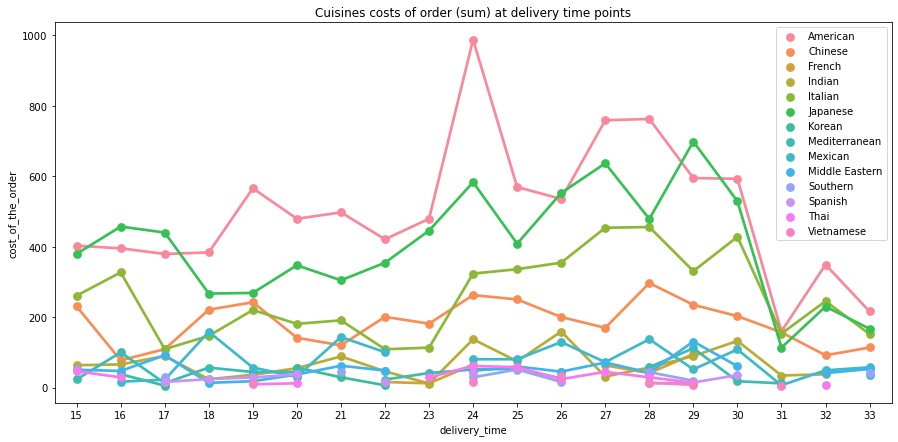

```python
# Add hue parameter to the pointplot to plot for each cuisine
plt.figure(figsize=(15, 7))
sns.pointplot(x='delivery_time', y='cost_of_the_order', data=df, estimator=sum, ci=None, hue = 'cuisine_type')
plt.title('Cuisines costs of order (sum) at delivery time points')
plt.legend(bbox_to_anchor=(1, 1))
plt.show()
```

### Question 13: Suppose the company wants to provide a promotional offer in the advertisement of the restaurants. The condition to get the offer is that the restaurants must have a rating count of more than 50 and the average rating should be greater than 4. Write the code to find the restaurants fulfilling the criteria to get the promotional offer. (2 marks)

```python
# write the code here

# copying data again just in case
df3 = df.copy()
```

```python
# ===================================
# KEY ASSUMPTION
# observations that have the value of 'Not given' are not explicite ratings from end users, but rather...
# ...represent a lack of rating or a lack of action to rate a particular order. For this reason, in my...
# ...approach, I chose to drop any such observations/rows from the dataset analysis.
# ===================================

df3 = df3[df.rating != 'Not given']
df3

# in the table below, we can see that such non-ratings are dropped, and we can also see...
# ... that the number of rows is now reduced to 1,162 (or 1898 original rows less 736 'Not given' rows)
```

|  | order_id | customer_id | restaurant_name | cuisine_type | cost_of_the_order | day_of_the_week | rating | food_preparation_time | delivery_time |
| --- | --- | --- | --- | --- | --- | --- | --- | --- | --- |
| 0 | 1477004 | 250494 | Five Guys Burgers and Fries | American | 33.03 | Weekend | 5 | 29 | 15 |
| 1 | 1477334 | 106968 | Blue Ribbon Fried Chicken | American | 29.20 | Weekend | 3 | 25 | 15 |
| 2 | 1477856 | 143984 | The Smile | American | 25.17 | Weekend | 3 | 31 | 15 |
| 4 | 1478397 | 121706 | Blue Ribbon Fried Chicken | American | 24.30 | Weekend | 5 | 22 | 15 |
| 5 | 1477694 | 192317 | Shake Shack | American | 24.30 | Weekend | 4 | 25 | 15 |
| ... | ... | ... | ... | ... | ... | ... | ... | ... | ... |
| 1892 | 1476837 | 147468 | Nha Trang One | Vietnamese | 15.67 | Weekday | 3 | 23 | 24 |
| 1893 | 1477189 | 54630 | V-Nam Cafe | Vietnamese | 22.26 | Weekend | 5 | 33 | 26 |
| 1894 | 1477555 | 361497 | V-Nam Cafe | Vietnamese | 12.13 | Weekend | 4 | 20 | 26 |
| 1896 | 1477014 | 399520 | Xe May Sandwich Shop | Vietnamese | 7.96 | Weekend | 5 | 25 | 29 |
| 1897 | 1478373 | 40808 | V-Nam Cafe | Vietnamese | 6.01 | Weekday | 3 | 20 | 31 |

1162 rows × 9 columns

```python
### change the 'rating' data to 'int64' so that we can analyze as needed in the question number 13.
df3['rating'] = df3.rating.astype('int64')

# double-check that the 'rating' data has been changed.
df3.info()
```

```
<class 'pandas.core.frame.DataFrame'>
Int64Index: 1162 entries, 0 to 1897
Data columns (total 9 columns):
 #   Column                 Non-Null Count  Dtype
---  ------                 --------------  -----
 0   order_id               1162 non-null   int64
 1   customer_id            1162 non-null   int64
 2   restaurant_name        1162 non-null   category
 3   cuisine_type           1162 non-null   category
 4   cost_of_the_order      1162 non-null   float64
 5   day_of_the_week        1162 non-null   category
 6   rating                 1162 non-null   int64
 7   food_preparation_time  1162 non-null   int64
 8   delivery_time          1162 non-null   int64
dtypes: category(3), float64(1), int64(5)
memory usage: 74.3 KB
```

```python
# let's look at the top restaurants by ratings count (with 'Not given' observations excluded per the above)

ratings_count=df3.groupby('restaurant_name')['rating'].count().sort_values(ascending=False).reset_index()
ratings_count.rename(columns={'rating':'count_of_ratings'},inplace=True)
ratings_count.head()
```

|  | restaurant_name | count_of_ratings |
| --- | --- | --- |
| 0 | Shake Shack | 133 |
| 1 | The Meatball Shop | 84 |
| 2 | Blue Ribbon Sushi | 73 |
| 3 | Blue Ribbon Fried Chicken | 64 |
| 4 | RedFarm Broadway | 41 |

```python
# let's also find restaurants with rating means

mean_rating=df3.groupby('restaurant_name')['rating'].mean().sort_values(ascending=False).reset_index()
mean_rating.rename(columns={'rating':'mean_of_ratings'},inplace=True)
mean_rating.head()
```

|  | restaurant_name | mean_of_ratings |
| --- | --- | --- |
| 0 | 'wichcraft | 5.0 |
| 1 | Ravagh Persian Grill | 5.0 |
| 2 | Chola Eclectic Indian Cuisine | 5.0 |
| 3 | Chote Nawab | 5.0 |
| 4 | Junoon | 5.0 |

```python
# now merge the two tables on inner to find only those observations that are represented in both datasets

df_merge = ratings_count.merge(mean_rating, on = 'restaurant_name', how = 'inner')
df_merge.head()
```

|  | restaurant_name | count_of_ratings | mean_of_ratings |
| --- | --- | --- | --- |
| 0 | Shake Shack | 133 | 4.278195 |
| 1 | The Meatball Shop | 84 | 4.511905 |
| 2 | Blue Ribbon Sushi | 73 | 4.219178 |
| 3 | Blue Ribbon Fried Chicken | 64 | 4.328125 |
| 4 | RedFarm Broadway | 41 | 4.243902 |

```python
# while the above table intuitively provides the solution's answer on the restaurants that meet the criteria...
# ...let's use a specific formula to deliver the needed results by merging the two.

df_merge[(df_merge.count_of_ratings > 50) & (df_merge.mean_of_ratings > 4)]
```

|  | restaurant_name | count_of_ratings | mean_of_ratings |
| --- | --- | --- | --- |
| 0 | Shake Shack | 133 | 4.278195 |
| 1 | The Meatball Shop | 84 | 4.511905 |
| 2 | Blue Ribbon Sushi | 73 | 4.219178 |
| 3 | Blue Ribbon Fried Chicken | 64 | 4.328125 |

#### Observations:

- As we can see from the above table, only 4 restaurants are really eligible for our promotional offer.
- That means that only 'Shake Shack', 'The Meatball Shop', 'Blue Ribbon Sushin', and 'Blue Ribbon Fried Chicken' restaurants have more than 50 ratings each, and all four resetaurants simultaneously have their mean ratings above 4.

### Question 14: Suppose the company charges the restaurant 25% on the orders having cost greater than 20 dollars and 15% on the orders having cost greater than 5 dollars. Write the code to find the net revenue generated on all the orders given in the dataset. (2 marks)

```python
# write the code here

# ===================================
# KEY ASSUMPTION
# the company will charge the 15% surcharge on orders greater than 5 AND smaller than 20 dollars, and...
# ...will simultanously charge the 25% surcharge on orders over 20 dollars.
# the company will not make any money on orders below 5 dollars, so those will be removed.
#
# Additionally, since we are observing only the "net revenue", I assume that we will measure only ...
# ...the revenue received from surcharges, AND NOT the total revenue (surcharges + cost of order).
# ===================================
```

```python
df4 = df.copy()  # first copy the dataset to prevent data loss
df4 = df4[df.cost_of_the_order>5]  # only look at orders above 5 dollars
# below formula uses lambda for quicker execution via if/else statement for both types of surcharges
net_profit=df4['cost_of_the_order'].apply(lambda x : x*.25 if x>20 else (x*.15 if x>5 else x)).sum() # orders sum

print("Net revenue from both surcharges combined: ${:,.2f}".format(net_profit)) # response formatted
```

```
Net revenue from both surcharges combined: $6,166.30
```

```python
# compared to the sum of total orders delivered and processed

total_orders_processed=df['cost_of_the_order'].sum()
print("Total revenue processed for restaurants: ${:,.2f}".format(total_orders_processed))
```

```
Total revenue processed for restaurants: $31,314.82
```

#### Observations:

- In the dataset provided, the company helps restaurants process a total of around 31,314.82 dollars from almost 1900 orders.
- If the company was to apply 25% surcharge for orders over 20 AND 15% surcharge for orders between 5 AND 20 dollars, the company would make a net revenue of around 6,166.30 dollars in the given time period.
- That's around 20% markup on all processed orders.

### Question 15: Suppose the company wants to analyze the total time required to deliver the food. Write the code to find out the percentage of orders that have more than 60 minutes of total delivery time. (2 marks)

Note: The total delivery time is the summation of the food preparation time and delivery time.

```python
# write the code here

# copying data again just in case into dataframe 2 (df2)
df5 = df.copy()
```

```python
tot_del=df5['food_preparation_time']+df5['delivery_time']  # add up the food prep time and delivery time
df5['total_delivery']=tot_del # create a new column in dataset called 'total_delivery'
df5.head()

# dataframe (df5) below shows that the new column has been with correct sum under 'total_delivery'
```

|  | order_id | customer_id | restaurant_name | cuisine_type | cost_of_the_order | day_of_the_week | rating | food_preparation_time | delivery_time | total_delivery |
| --- | --- | --- | --- | --- | --- | --- | --- | --- | --- | --- |
| 0 | 1477004 | 250494 | Five Guys Burgers and Fries | American | 33.03 | Weekend | 5 | 29 | 15 | 44 |
| 1 | 1477334 | 106968 | Blue Ribbon Fried Chicken | American | 29.20 | Weekend | 3 | 25 | 15 | 40 |
| 2 | 1477856 | 143984 | The Smile | American | 25.17 | Weekend | 3 | 31 | 15 | 46 |
| 3 | 1477503 | 99621 | Westville Hudson | American | 24.30 | Weekend | Not given | 32 | 15 | 47 |
| 4 | 1478397 | 121706 | Blue Ribbon Fried Chicken | American | 24.30 | Weekend | 5 | 22 | 15 | 37 |

```python
# find the count of orders with delivery times longer than 60 min using count

delivery_over_60=df5[df5.total_delivery>60]['order_id'].count()
print("Total number of orders delivered at over 60 minute timeline:", delivery_over_60)
```

```
Total number of orders delivered at over 60 minute timeline: 200
```

```python
# recall the number of total orders from previous tasks in this paper.
print("Total number of orders:",total_orders)
```

```
Total number of orders: 1898
```

```python
# calculate the percentage by dividing over 60 delivery minutes orders by the total orders.

percent = (delivery_over_60/total_orders)*100
# using the 'round' function to limit the number od decimals to two (2)
print(round(percent,2),"percent of all orders have more than 60 minutes of total delivery time.")
```

```
10.54 percent of all orders have more than 60 minutes of total delivery time.
```

#### Observations:

- Just a little over 10% of all orders take longer than 60 minutes to both, prepare and deliver.
- That is 1/10th of all orders.

### Question 16: Suppose the company wants to analyze the delivery time of the orders on weekdays and weekends. Write the code to find the mean delivery time on weekdays and weekends. Write your observations on the results. (2 marks)

```python
# write the code here

# using the mean() function below for weekends and rounding off the result to 2 decimal points
mean_weekends=df[df.day_of_the_week=='Weekend']['delivery_time'].mean()
print("Delivery mean for all orders on weekends is:", round(mean_weekends,2))
```

```
Delivery mean for all orders on weekends is: 22.47
```

```python
# using the mean() function below for weekdays and rounding off the result to 2 decimal points
mean_weekdays=df[df.day_of_the_week=='Weekday']['delivery_time'].mean()
print("Delivery mean for all orders on weekdays is:", round(mean_weekdays,2))
```

```
Delivery mean for all orders on weekdays is: 28.34
```

#### Observations:

- Delivery mean for all orders on weekends is approximately 6 minutes shorter than the delivery mean for all orders on weekdays. This might suggest that weekdays are generally busier, and therefore it might take drivers longer time to deliver meals. To maintain consistent stream of revenue during peak hours, FoodHub should ensure strong pool of drivers during peak hours.

## Conclusion and Recommendations

### **Question 17:** Write the conclusions and business recommendations derived from the analysis. (3 marks)

#### Conclusion Intro:

We analyzed a dataset provided of around 1,900 orders as the FoodHub food aggregator helped local restaurants to generate a total revenue of around $31.3k. Our objective was to analyze the data and get a fair idea about the demand of different restaurants and their cuisines, which will help FoodHub to enhance their customer experience. With that in mind, we observed univariate, bivariate, and multivariate analysis of the data in relationship to 7 different data categories, such as delivery times, cuisine types, day of the week, cost of the order, ratings, restaurants themselves, and food preparation times.

### Key Insights Categories

#### And the "Other" Cuisines

- Indian cuisine receives very few ratings of 3, just like Southern, while Spanish, and Thai get no 3s.
- Middle Eastern cuisine receives 5s at highest IQR delivery times distribution while lower delivery time distributions have mostly the rating of 3 (seems very counterintuitive), but perhaps long times spent on waiting for food are associated with high(er) quality?
- Meanwhile, Southern cuisine 'Not given' IQR seems to be associated almost exclusively at 26 minutes and higher.
- There is an interesting "floor" in the 25th quartile of most cuisine types except for the Vietnamese cuisine when it comes to cost of the order distribution.
- Korean and Vietnamese cuisine restaurants appear to have the smallest range of menu prices.
- Spanish cuisine seems almost completely absent from weekdays.

> **Current Recommendations**:
> - Since certain cuisine types (and therefore restaurants serving such foods) are more resistant to poor ratings (receive less ratings of 3), the company could push out various promotions to increase awareness and orders from such restaurants. The hope would be that even with increased demand, such cuisines would be able to continue to maintain higher order ratings - making FoodHub look good.
> - To reduce the demand on certain cuisines (and their restaurants), especially during delivery peak times, FoodHub could work with under-represented cuisines type restaurants during certain times of the week to push more customers their way. For example, with Spanish cuisine being almost completely underutilized during weekdays, which are busier delivery and food preparation times, FoodHub could send more customers towards Spanish cuisine restaurants and offload some of the pressure and demand on other popular cuisine restaurants. Similarly, Korean cuisine seems to lead in terms of record food preparation speeds on both weekdays and weekends. Incentivizing more customers to order from Korean restaurants could offload some of the pressure from dominant cuisines and compensate for the higher delivery times with lower food preparation times.

> **Future Exploration**:
> - It would be great to understand which cuisines are popular on each day of the week, so that particular restaurant or cuisines promotions can be pushed out on such days.

#### Restaurants

- Top 5 restaurants are Shake Shack, The Meatball Shop, Blue Ribbon Sushi, Blue Ribbon Fried Chicken, followed by Parm. The bottom 5 are Klong, Kambi Ramen House, Il Bambino, Hunan Manor, and Lamarca Pasta.
- Not too many restaurants receive a large number of orders, and therefore they get a smaller number of reviews. In fact, only 4 restaurants are eligible for our promotional offer because they have over 50 reviews with mean rating above 4.
- The highest order cost of 35.41 dollars was for Pylos, the Mediterranean cuisine restaurant.

> **Current Recommendations**:
> - There is an imaginary "floor" in the 25th quartile of most cuisine types at around 12.5 dollars, and yet the 75th percentile seems to vary a lot. This could suggest that a price elasticity exists around the 75th quartile, and that there is an openness of customer personas with deeper pockets to accept higher cost of orders for different cuisines. With exception of Korean and Vietnamese cuisines (restaurants), which seem to have smaller IQR ranges, and likely customers with smaller pockets, FoodHub could work with other cuisine restaurants to promote delivery specials. They could jointly push more specials out, and possible higher prices to particular persona types with higher orders costs by allowing such customers to venture out into the less explored but more unique cuisines with bigger tolerances for higher cost of orders (e.g. Southern, Middle Eastern, Indian and French).

> **Future Exploration**:
> - It would be great to acquire the local areas demographic data to better understand which restaurants and cuisines to incentivize and promote.

#### Revenue and Cost of Order

- While there’s a wide range of order costs, from 5-35 dollars, largest count of order costs is between 11-17 dollars.
- If FoodHub applied a 25% surcharge for orders over 20 AND 15% surcharge for orders between 5 AND 20 dollars, the company would make a net revenue of around 6,166.30 dollars in the given time period -- around 20% markup all together.
- There is not a significant correlation between cost of orders, and order delivery or preparation times.
- As delivery times increase, past the 30-minute deliveries, most cuisine order value sums drop to various extents.

> **Current Recommendations**:
> - Over 29% of all orders in the dataset are over 20 dollars -- almost 1/3. And, as a percentage of total revenue, such orders represent nearly half of all orders revenue, or 47.12% of revenue. The company should use this as a sign to push forward and experiment with small surcharges right away on larger orders, therefore contributing immediatelly to its bottom line revenue.

> **Future Exploration**:
> - There doesn't seem to be a significant impact of order delivery or preparation times on cost of orders, with exception of delivery times exceeding 30-minute deliveries. There is potentially a sign that there is a level of price elasticity that exists on the market. The company could explore and experiment with higher delivery surcharges in order to extract more net revenue from end users, given that there is a sufficient number of drivers to maintain order delivery times below 30-minute mark.
> - Going forward in analysis, it would be interesting to understand the cost of orders that take longer to prepare and deliver, and use that information to reshape profit plans and methodologies. For example, orders that take long to prepare and deliver, might be charged higher delivery surcharges or similar to compensate for poorer ratings or dropped orders/customer adjustments.

#### Ratings

- There are 736 orders that are not rated (marked with 'Not given'). That’s nearly over 1/3 of observations that don’t have ratings or 38.8% of all possible ratings.
- Ratings 4 & 5 represent just over 51% of all ratings.
- On weekdays, food preparation times seem to have an equal representation amongst all order ratings.
- On weekends, 75th percentile food preparation distribution times, and higher food prep times, seem to represent lower ratings of 3 and 4. We could intuitively assume that during weekends, longer food preparation times are more prone to the rating marks below 5.
- On weekends, food delivery times with slightly higher 75th percentile distributions seem to represent lower ratings of 3 or 'Not given' ratings. We could intuitively assume that during weekends, slightly longer upper percentile food delivery times are more prone to the lower rating marks -- below 5.
- On weekdays, delivery times seem to have a type of a sensitivity to rating of 3 even with overall lower IQR from 26-30.

> **Current Recommendations**:
> - With only 50% of all ratings on the positive side, the company should strive to improve its negative ratings in the areas such as: reduced delivery times for the restaurants in the cuisine types that are prone to lower ratings with increased delivery times (e.g. Vietnamese, Mexican, and Japanese to mention a few).

> **Future Exploration**:
> - Attempt to understand why as many as 38.8% of all possible ratings were not provided ('Not given'). Having more reviews and ratings would help the company have a better perception of its value, utilization, and feature usability for future improvements.
> - The company should find the way to incentivize their customers to rate more deliveries, and possibly provide reasons for rating, not just rating numbers.

#### Weekdays/Weekends and Delivery Times

- Over 71% of all orders happen on weekends.
- On weekdays, range of delivery times shifts considerably towards the range of 24-33 minutes, with IQR from 26-31 minutes. This could potentially indicate that during weekday rush hour, most orders take longer to be delivered.
- Orders between 15-min delivery time (lowest point) and 23-min delivery times happen only on weekends.
- A count of very high delivery times, between 31-33 minutes, happens only on weekdays, possibly suggesting work rush hour times.
- Just a little over 10% of all orders take longer than 60 minutes to both, prepare and deliver. That is 1/10th of all orders.
- While most cuisine types have similar food preparation times, Korean cuisine seems to lead in terms of record food preparation speeds on both weekdays and weekends.

> **Current Recommendations**:
> - The company should ensure that enough delivery drivers are available in the peak traffic rush hours during weekdays, when delivery times on average take longer. It's important to add that cost of order sums for most cuisine types drops after 30 minutes marks suggesting various negative dynamics at play once delivery times pass the 30-minute mark, including less revenue.
> - On weekends, delivery drivers' availability should be ensured once IQR of delivery times starts reaching between 21-26 min or extending beyond the 26 minutes mark.
> - On weekdays, delivery drivers' availability should be ensured once IQR of delivery times start reaching between 25-30.

> **Future Exploration**:
> - From the further analysis, it would be great to understand which specific days (if data is available) have the most observed orders in order to understand how to distribute drivers during those days.
> - It would also be great to understand which days have the best order reviews.